# Exploring the Titanic Dataset

原作者:Megan L. Risdal

# 1 原作者的Introduction

This is my first stab at a Kaggle script. I have chosen to work with the Titanic dataset after spending some time poking around on the site and looking at other scripts made by other Kagglers for inspiration. I will also focus on doing some illustrative data visualizations along the way. I’ll then use `randomForest` to create a model predicting survival on the Titanic. I am new to machine learning and hoping to learn a lot, so feedback is very welcome!

There are three parts to my script as follows:

- Feature engineering
- Missing value imputation
- Prediction!

# 2 首先用install.packages()在Console下載檔案，之後在用library讀取他們。

## 2.1 Load and check data

```r
# Load packages
library('ggplot2') # visualization
library('ggthemes') # visualization
library('scales') # visualization
library('dplyr') # data manipulation
library('mice') # imputation
library('randomForest') # classification algorithm
```

Now that our packages are loaded, let’s read in and take a peek at the data.

# 3 然後再用函數read.csv()找到我們train 跟 test的資料，並打他們用bind_rows合併成full，再用str()來確認full的檔案形式。

```r
train <- read.csv('../week3/all/train.csv', stringsAsFactors = F)
test  <- read.csv('../week3/all/test.csv', stringsAsFactors = F)

full  <- bind_rows(train, test) # bind training & test data

# check data
str(full)
```

```
## 'data.frame':    1309 obs. of  12 variables:
##  $ PassengerId: int  1 2 3 4 5 6 7 8 9 10 ...
##  $ Survived   : int  0 1 1 1 0 0 0 0 1 1 ...
##  $ Pclass     : int  3 1 3 1 3 3 1 3 3 2 ...
##  $ Name       : chr  "Braund, Mr. Owen Harris" "Cumings, Mrs. John Bradley (Florence Briggs Thayer)" "Heikkinen, Miss. Laina" "Futrelle, Mrs. Jacques Heath (Lily May Peel)" ...
##  $ Sex        : chr  "male" "female" "female" "female" ...
##  $ Age        : num  22 38 26 35 35 NA 54 2 27 14 ...
##  $ SibSp      : int  1 1 0 1 0 0 0 3 0 1 ...
##  $ Parch      : int  0 0 0 0 0 0 0 1 2 0 ...
##  $ Ticket     : chr  "A/5 21171" "PC 17599" "STON/O2. 3101282" "113803" ...
##  $ Fare       : num  7.25 71.28 7.92 53.1 8.05 ...
##  $ Cabin      : chr  "" "C85" "" "C123" ...
##  $ Embarked   : chr  "S" "C" "S" "S" ...
```

# 4 Feature Engineering

## 4.1 之後來做一些特徵工程，來選取這份資料中比較有關連性的資料，首先原作者選擇先從名字下手，他用$將Name從full這個檔案中選取出來並用gsub()**刪掉姓氏跟名字**，只留下稱謂，放在**Title**欄位，再用table列表出來。

## 4.2 再來從table裡面找出比較少出現的稱謂並命名rare_title，並把其他Mr, Miss的用法用full$Title[full$Title == ‘xxx’] <- ’Miss or Mrs’將其變回Mr, Miss.

## 4.3 再用table顯示，確認欄位正確。

## 4.4 然後用strsplit()將名字切割，讓他剩下surname，並用sapply迴圈跑完全部，nlevels則是可以拿來計算，取得因子的數量。paste則是將其串聯起來，cat則output結果。

```r
# Grab title from passenger names
full$Title <- gsub('(.*, )|(\\..*)', '', full$Name)

# Show title counts by sex
table(full$Sex, full$Title)
```

```
##
##          Capt Col Don Dona  Dr Jonkheer Lady Major Master Miss Mlle Mme
##   female    0   0   0    1   1        0    1     0      0  260    2   1
##   male      1   4   1    0   7        1    0     2     61    0    0   0
##
##           Mr Mrs  Ms Rev Sir the Countess
##   female   0 197   2   0   0            1
##   male   757   0   0   8   1            0
```

```r
# Titles with very low cell counts to be combined to "rare" level
rare_title <- c('Dona', 'Lady', 'the Countess','Capt', 'Col', 'Don',
                'Dr', 'Major', 'Rev', 'Sir', 'Jonkheer')

# Also reassign mlle, ms, and mme accordingly
full$Title[full$Title == 'Mlle']        <- 'Miss'
full$Title[full$Title == 'Ms']          <- 'Miss'
full$Title[full$Title == 'Mme']         <- 'Mrs'
full$Title[full$Title %in% rare_title]  <- 'Rare Title'

# Show title counts by sex again
table(full$Sex, full$Title)
```

```
##
##          Master Miss  Mr Mrs Rare Title
##   female      0  264   0 198          4
##   male       61    0 757   0         25
```

```r
# Finally, grab surname from passenger name
full$Surname <- sapply(full$Name,
                      function(x) strsplit(x, split = '[,.]')[[1]][1])
```

```r
cat(paste('We have <b>', nlevels(factor(full$Surname)), '</b> unique surnames.'))
```

We have **875** unique surnames.

## 4.5 Do families sink or swim together?

## 4.6 而這裡我們要將家庭大小歸類出來，用$將他們家人及手足選取並相加在一起，用paste()將全部串起來。

```r
# Create a family size variable including the passenger themselves
full$Fsize <- full$SibSp + full$Parch + 1

# Create a family variable
full$Family <- paste(full$Surname, full$Fsize, sep='_')
```

## 4.7 用ggplot2來畫圖表，設X軸等於Fsize,然後畫出家庭大小和生存率的關係。

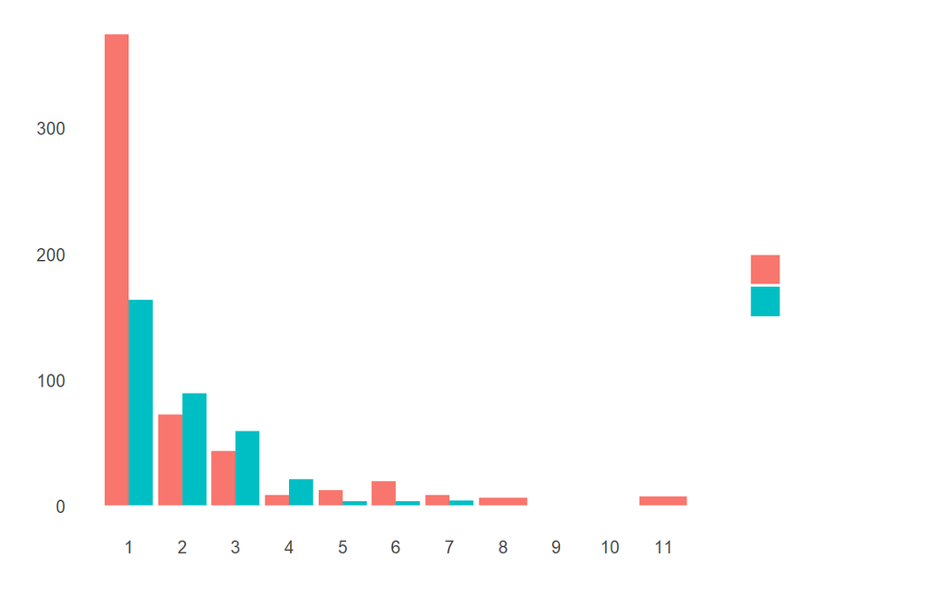

```r
ggplot(full[1:891,], aes(x = Fsize, fill = factor(Survived))) +
  geom_bar(stat='count', position='dodge') +
  scale_x_continuous(breaks=c(1:11)) +
  labs(x = 'Family Size') +
  theme_few()
```

## 4.8 然後將family size分組，有分只有一人的singleton，1<人數<5的small，人數>4的large，最後再用mosaic plot秀出Family Size by Survival。

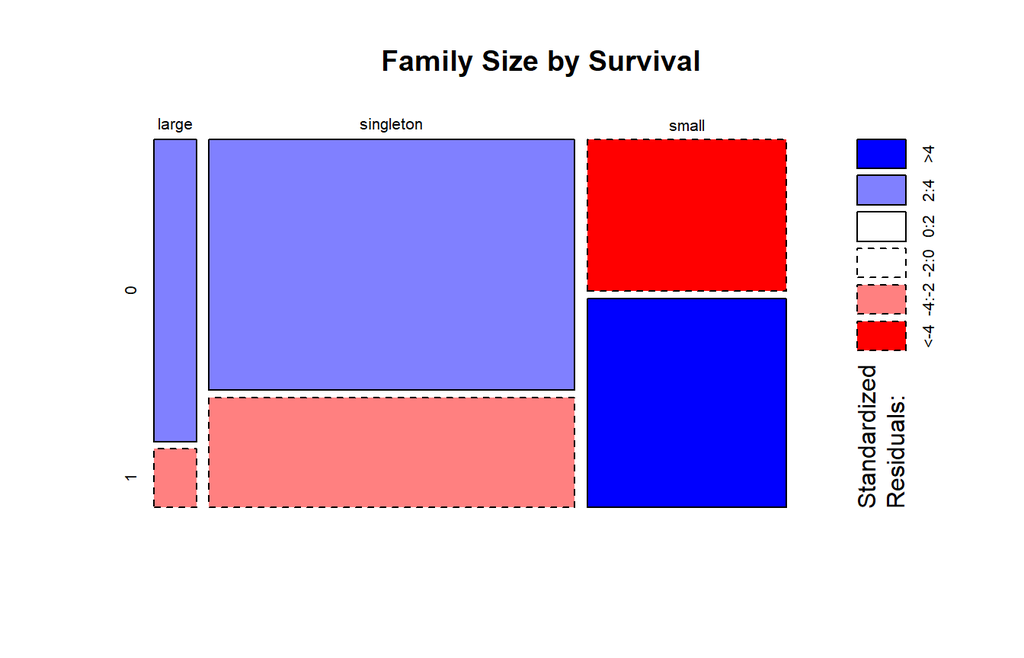

```r
# Discretize family size
full$FsizeD[full$Fsize == 1] <- 'singleton'
full$FsizeD[full$Fsize < 5 & full$Fsize > 1] <- 'small'
full$FsizeD[full$Fsize > 4] <- 'large'

# Show family size by survival using a mosaic plot
mosaicplot(table(full$FsizeD, full$Survived), main='Family Size by Survival', shade=TRUE)
```

## 4.9 試試看其他變數

**passenger cabin**裡面有關於**deck**的資料，可以將deck的資料分成A - F，但是因為資料有點稀疏，所以原作者並沒有繼續做下去，這裡作者也是先用strsplit打散甲板的編號，並用sapply迴圈跑完全部。

```r
# This variable appears to have a lot of missing values
full$Cabin[1:28]
```

```
##  [1] ""            "C85"         ""            "C123"        ""
##  [6] ""            "E46"         ""            ""            ""
## [11] "G6"          "C103"        ""            ""            ""
## [16] ""            ""            ""            ""            ""
## [21] ""            "D56"         ""            "A6"          ""
## [26] ""            ""            "C23 C25 C27"
```

```r
# The first character is the deck. For example:
strsplit(full$Cabin[2], NULL)[[1]]
```

```
## [1] "C" "8" "5"
```

```r
# Create a Deck variable. Get passenger deck A - F:
full$Deck<-factor(sapply(full$Cabin, function(x) strsplit(x, NULL)[[1]][1]))
```

# 5 Missingness

在這邊作者嘗試復原一些丟失的資料，像是乘客62跟830的Embarkment缺失了，作者使用他們的票錢以及他們的登陸班次來推算，所以他先pipe full並用filter過濾出了他想要的資料，並用ggplot畫出fare跟factor之間的關係，作者從第一班以及價錢在80這兩點對比圖片，發現他們是從C embarked的，然後將資料補足。

## 5.1 Sensible value imputation

```r
# Passengers 62 and 830 are missing Embarkment
full[c(62, 830), 'Embarked']
```

```
## [1] "" ""
```

```r
cat(paste('We will infer their values for **embarkment** based on present data that we can imagine may be relevant: **passenger class** and **fare**. We see that they paid<b> $', full[c(62, 830), 'Fare'][[1]][1], '</b>and<b> $', full[c(62, 830), 'Fare'][[1]][2], '</b>respectively and their classes are<b>', full[c(62, 830), 'Pclass'][[1]][1], '</b>and<b>', full[c(62, 830), 'Pclass'][[1]][2], '</b>. So from where did they embark?'))
```

We will infer their values for **embarkment** based on present data that we can imagine may be relevant: **passenger class** and **fare**. We see that they paid **$ 80** and **$ NA** respectively and their classes are **1** and **NA** . So from where did they embark?

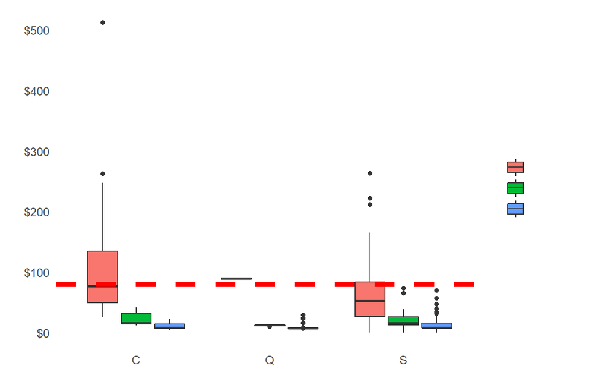

```r
# Get rid of our missing passenger IDs
embark_fare <- full %>%
  filter(PassengerId != 62 & PassengerId != 830)

# Use ggplot2 to visualize embarkment, passenger class, & median fare
ggplot(embark_fare, aes(x = Embarked, y = Fare, fill = factor(Pclass))) +
  geom_boxplot() +
  geom_hline(aes(yintercept=80),
    colour='red', linetype='dashed', lwd=2) +
  scale_y_continuous(labels=dollar_format()) +
  theme_few()
```

```r
# Since their fare was $80 for 1st class, they most likely embarked from 'C'
full$Embarked[c(62, 830)] <- 'C'
```

## 5.2 另外他也發現row 1044也有缺少票錢的資料，所以她也使用一樣的畫圖方法去比較，他從登陸地點S跟登陸班次推算出少的資料的價錢是8.05元，最後將資料補足。

```r
# Show row 1044
full[1044, ]
```

```
##      PassengerId Survived Pclass               Name  Sex  Age SibSp Parch
## 1044        1044       NA      3 Storey, Mr. Thomas male 60.5     0     0
##      Ticket Fare Cabin Embarked Title Surname Fsize   Family    FsizeD
## 1044   3701   NA              S    Mr  Storey     1 Storey_1 singleton
##      Deck
## 1044 <NA>
```

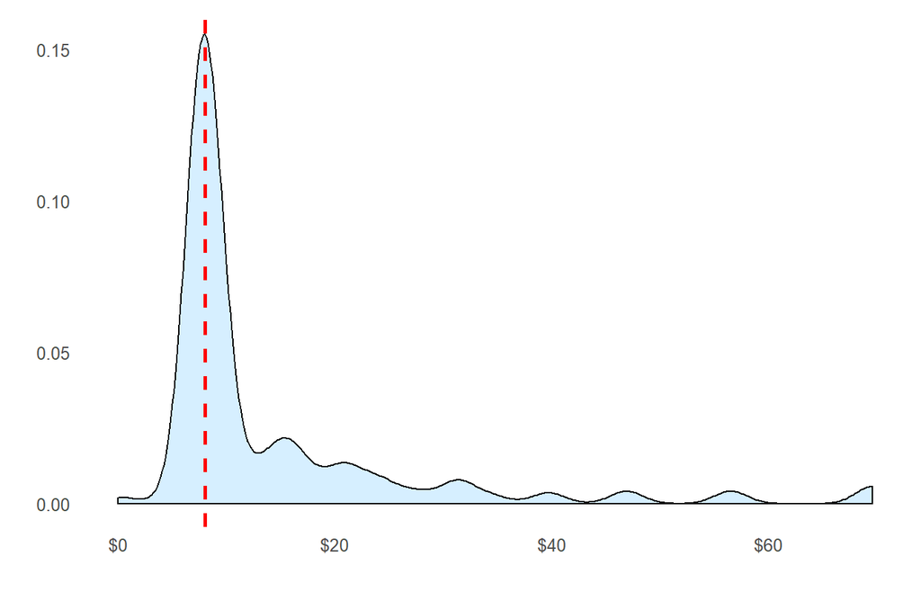

```r
ggplot(full[full$Pclass == '3' & full$Embarked == 'S', ],
  aes(x = Fare)) +
  geom_density(fill = '#99d6ff', alpha=0.4) +
  geom_vline(aes(xintercept=median(Fare, na.rm=T)),
    colour='red', linetype='dashed', lwd=1) +
  scale_x_continuous(labels=dollar_format()) +
  theme_few()
```

```r
# Replace missing fare value with median fare for class/embarkment
full$Fare[1044] <- median(full[full$Pclass == '3' & full$Embarked == 'S', ]$Fare, na.rm = TRUE)
```

# 6 Predictive imputation

## 6.1 現在作者要補齊消失的Age data，他使用mice package來幫助他，首先他先將變數收進一個集合之中，然後開始使用lapply迴圈，最後把它套進mice的model裡面，把圖畫出來，然後把得到的年齡資料套進去Full裏頭的age。

```r
# Show number of missing Age values
sum(is.na(full$Age))
```

```
## [1] 263
```

```r
# Make variables factors into factors
factor_vars <- c('PassengerId','Pclass','Sex','Embarked',
                 'Title','Surname','Family','FsizeD')

full[factor_vars] <- lapply(full[factor_vars], function(x) as.factor(x))

# Set a random seed
set.seed(129)

# Perform mice imputation, excluding certain less-than-useful variables:
mice_mod <- mice(full[, !names(full) %in% c('PassengerId','Name','Ticket','Cabin','Family','Surname','Survived')], method='rf')
# Save the complete output
mice_output <- complete(mice_mod)
```

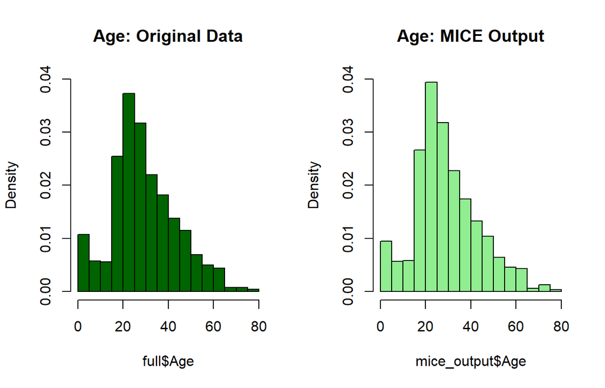

```r
# Plot age distributions
par(mfrow=c(1,2))
hist(full$Age, freq=F, main='Age: Original Data',
  col='darkgreen', ylim=c(0,0.04))
hist(mice_output$Age, freq=F, main='Age: MICE Output',
  col='lightgreen', ylim=c(0,0.04))
```

```r
# Replace Age variable from the mice model.
full$Age <- mice_output$Age

# Show new number of missing Age values
sum(is.na(full$Age))
```

```
## [1] 0
```

# 7 Feature Engineering: Round 2

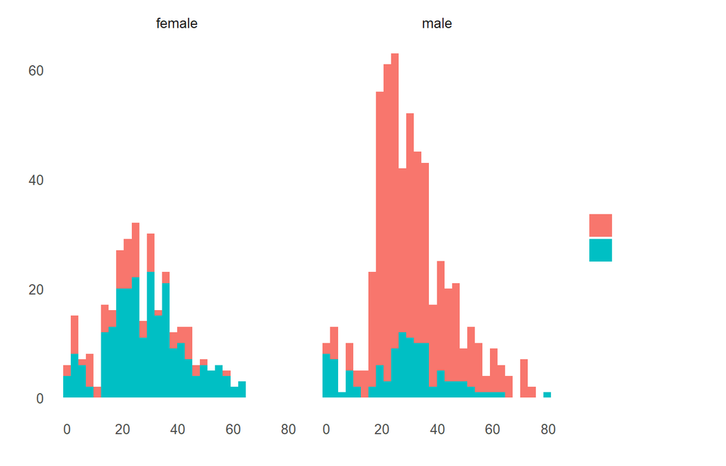

```r
ggplot(full[1:891,], aes(Age, fill = factor(Survived))) +
  geom_histogram() +
  facet_grid(.~Sex) +
  theme_few()
```

```r
# Create the column child, and indicate whether child or adult
full$Child[full$Age < 18] <- 'Child'
full$Child[full$Age >= 18] <- 'Adult'

# Show counts
table(full$Child, full$Survived)
```

```
##
##           0   1
##   Adult 481 272
##   Child  68  70
```

```r
# Adding Mother variable
full$Mother <- 'Not Mother'
full$Mother[full$Sex == 'female' & full$Parch > 0 & full$Age > 18 & full$Title != 'Miss'] <- 'Mother'

# Show counts
table(full$Mother, full$Survived)
```

```
##
##                0   1
##   Mother      16  39
##   Not Mother 533 303
```

```r
# Finish by factorizing our two new factor variables
full$Child  <- factor(full$Child)
full$Mother <- factor(full$Mother)
```

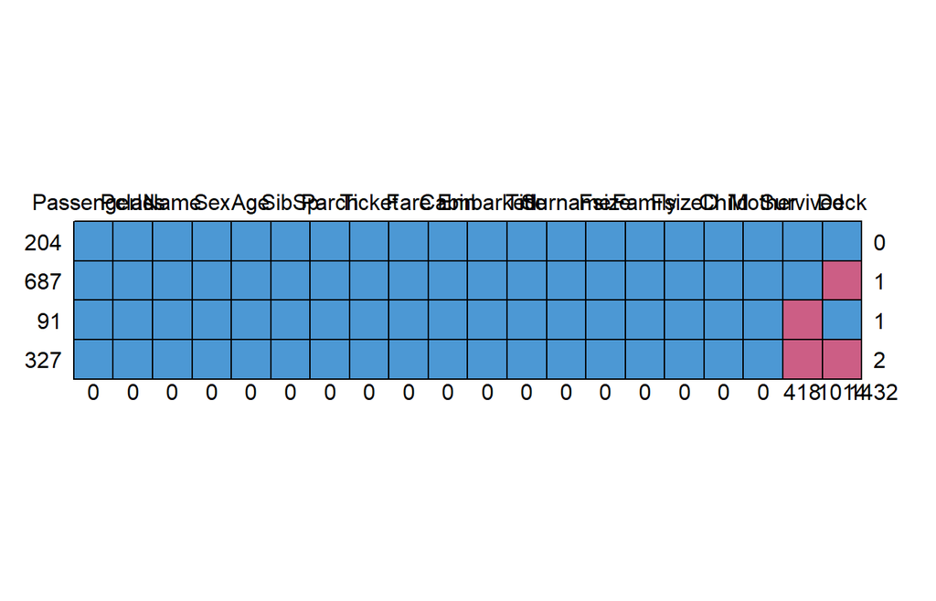

```
##     PassengerId Pclass Name Sex Age SibSp Parch Ticket Fare Cabin Embarked
## 204           1      1    1   1   1     1     1      1    1     1        1
## 687           1      1    1   1   1     1     1      1    1     1        1
## 91            1      1    1   1   1     1     1      1    1     1        1
## 327           1      1    1   1   1     1     1      1    1     1        1
##               0      0    0   0   0     0     0      0    0     0        0
##     Title Surname Fsize Family FsizeD Child Mother Survived Deck
## 204     1       1     1      1      1     1      1        1    1    0
## 687     1       1     1      1      1     1      1        1    0    1
## 91      1       1     1      1      1     1      1        0    1    1
## 327     1       1     1      1      1     1      1        0    0    2
##         0       0     0      0      0     0      0      418 1014 1432
```

```r
md.pattern(full)
```

# 8 Prediction

## 8.1 Split into training & test sets

### 8.1.1 將資料先分成train set 跟 test set。

```r
# Split the data back into a train set and a test set
train <- full[1:891,]
test <- full[892:1309,]
```

## 8.2 Building the model

### 8.2.1 作者用 `randomForest` 跟 training set做出自己的模型.

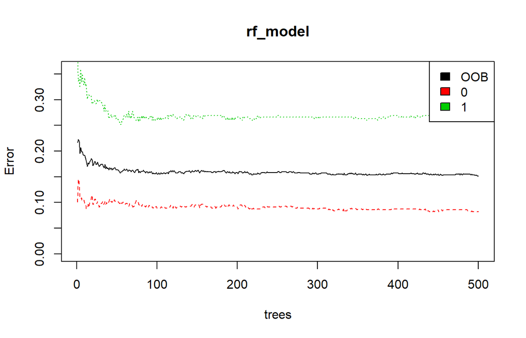

```r
# Set a random seed
set.seed(754)

# Build the model (note: not all possible variables are used)
rf_model <- randomForest(factor(Survived) ~ Pclass + Sex + Age + SibSp + Parch +
                                            Fare + Embarked + Title +
                                            FsizeD + Child + Mother,
                                            data = train)

# Show model error
plot(rf_model, ylim=c(0,0.36))
legend('topright', colnames(rf_model$err.rate), col=1:3, fill=1:3)
```

### 8.2.2 而用顯示出來的這個圖，可以看出我們的錯誤率，目前黑線顯現的是所有的錯誤率，而紅線是死亡的，可以看出作者現在做出的模型目前對於死亡的預測率，比較精準。

## 8.3 Variable importance

### 8.3.1 然後作者比較了其他變數與預測之間的關係，並用ggplot畫出來。

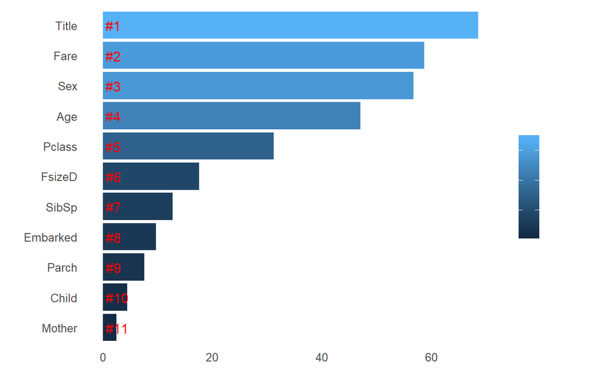

```r
# Get importance
importance    <- importance(rf_model)
varImportance <- data.frame(Variables = row.names(importance),
                            Importance = round(importance[ ,'MeanDecreaseGini'],2))

# Create a rank variable based on importance
rankImportance <- varImportance %>%
  mutate(Rank = paste0('#',dense_rank(desc(Importance))))

# Use ggplot2 to visualize the relative importance of variables
ggplot(rankImportance, aes(x = reorder(Variables, Importance),
    y = Importance, fill = Importance)) +
  geom_bar(stat='identity') +
  geom_text(aes(x = Variables, y = 0.5, label = Rank),
    hjust=0, vjust=0.55, size = 4, colour = 'red') +
  labs(x = 'Variables') +
  coord_flip() +
  theme_few()
```

## 8.4 Prediction!

### 8.4.1 最後隨之完成的就是作者的prediction model 了。

```r
# Predict using the test set
prediction <- predict(rf_model, test)

# Save the solution to a dataframe with two columns: PassengerId and Survived (prediction)
solution <- data.frame(PassengerID = test$PassengerId, Survived = prediction)

# Write the solution to file
write.csv(solution, file = 'rf_mod_Solution.csv', row.names = F)
```